# Week 3: Grouping, Summarizing, and Custom Visuals

Ronnie Bailey-Steinitz

2025-10-06

# Skills Learning – Lecture

This week we introduce only **two new functions** — `group_by()` and `summarise()` — and then spend most of the time visualizing data.

We’ll use the **gapminder** dataset, which includes demographic and economic data by country and year.

## 0. Load Required Packages

```r
library(tidyverse)
# install.packages("here")
library(here) # this package will help overcome issues with knitting and your working directory
```

## 1. Load Data

```r
data <- read_csv(here("Week 3/gapminder.csv")) %>%
  janitor::clean_names()
glimpse(data)   # quick look at variables
```

```
## Rows: 1,704
## Columns: 6
## $ country    <chr> "Afghanistan", "Afghanistan", "Afghanistan", "Afghanistan",…
## $ continent  <chr> "Asia", "Asia", "Asia", "Asia", "Asia", "Asia", "Asia", "As…
## $ year       <dbl> 1952, 1957, 1962, 1967, 1972, 1977, 1982, 1987, 1992, 1997,…
## $ life_exp   <dbl> 28.801, 30.332, 31.997, 34.020, 36.088, 38.438, 39.854, 40.…
## $ pop        <dbl> 8425333, 9240934, 10267083, 11537966, 13079460, 14880372, 1…
## $ gdp_percap <dbl> 779.4453, 820.8530, 853.1007, 836.1971, 739.9811, 786.1134,…
```

## 2. Grouping and Summarizing

### 2.1 group_by() + summarise()

```r
# We can get a summary statistic
mean(data$life_exp) # quick and easy way
```

```
## [1] 59.47444
```

```r
data %>% summarize(mean(life_exp, na.rm = TRUE)) # within a pipe
```

```
## # A tibble: 1 × 1
##   `mean(life_exp, na.rm = TRUE)`
##                            <dbl>
## 1                           59.5
```

```r
### Q: Now what happens when we add group_by()? =====================
# Example: average life expectancy by continent
data %>%
  dplyr::group_by(continent) %>%
  dplyr::summarise(mean_life_exp = mean(life_exp, na.rm = TRUE))
```

```
## # A tibble: 5 × 2
##   continent mean_life_exp
##   <chr>             <dbl>
## 1 Africa             48.9
## 2 Americas           64.7
## 3 Asia               60.1
## 4 Europe             71.9
## 5 Oceania            74.3
```

```r
### A: We get the mean by group, in this case, continent =====================

# We can summarize after applying a filter and then a grouping command
data1 <- data %>%
  filter(year == 2007) %>%
  dplyr::group_by(continent) %>%
  dplyr::summarise(mean_life_exp = mean(life_exp, na.rm = TRUE),
                   n_countries = n())

write_csv(data1, "Mean Life Expectancy by Continent.csv")
```

### 2.2 Summarize and Arrange

```r
data1 <- data %>%
  filter(continent != "Asia") %>%
  group_by(country) %>%
  summarise(max(pop))

# We can also add the information to a new variable in the dataset
data2 <- data %>%
  filter(continent != "Asia") %>%
  group_by(country) %>%
  summarize(max_pop = max(pop, na.rm = TRUE)) # summarize the maximum population size logged for this country
# notice that data2 is automatically arranged by the **name of the country**

# you can change the arrangement to the **population**!
data2 <- data %>%
  filter(continent != "Asia") %>%
  group_by(country) %>%
  summarize(max_pop = max(pop, na.rm = TRUE)) %>%
  arrange(max_pop) # <------------- ADD THIS ------------------
# now, data2 is arranged by increasing maximum population size

# you can also look at the summary stats of a filtered item
china <- data %>%
  dplyr::filter(country == "China") %>%
  dplyr::summarise(mean_life_exp = mean(life_exp),
                   mean_gdp_percap = mean(gdp_percap))
```

## 3. Visualizing Summaries

### 3.1 Boxplots – geom_boxplot()

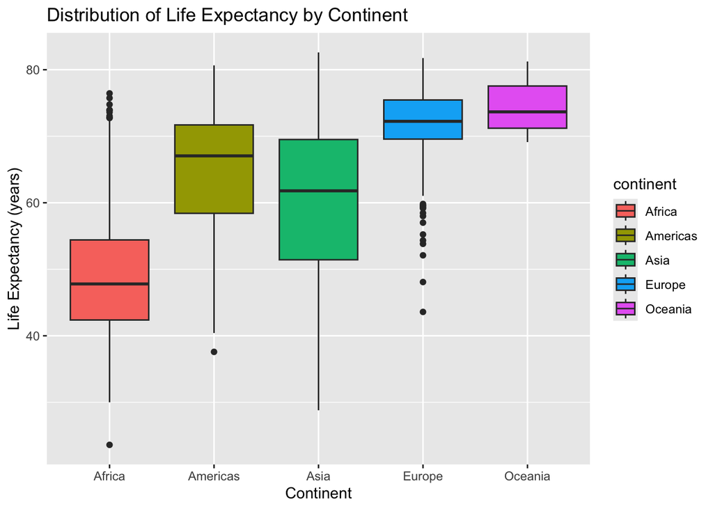

```r
# Show distribution of life expectancy by continent
ggplot(data, aes(x = continent, y = life_exp, fill = continent)) +
  geom_boxplot() +
  labs(title = "Distribution of Life Expectancy by Continent",
       x = "Continent", y = "Life Expectancy (years)")
```

### 3.2 Line plot – geom_line()

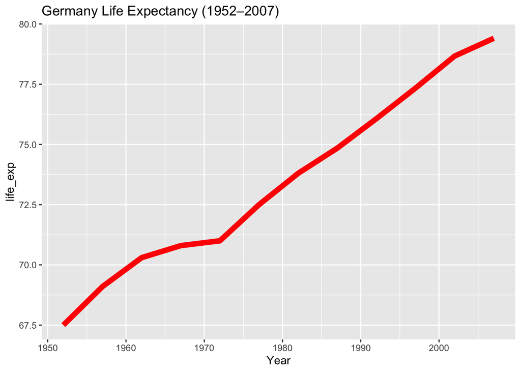

```r
# let's first filter the data to Germany only
germany <- data %>%
   dplyr::filter(country == "Germany")

ggplot(germany, aes(x = year, y = life_exp)) +
  geom_line(color = "red", size = 2.5) +
  labs(title = "Germany Life Expectancy (1952–2007)",
       x = "Year")
```

### Summarize by continent, year

```r
# summarizing relevant data
data3 <- data %>%
  group_by(continent) %>%
  summarize(mean_life_exp = mean(life_exp, na.rm = TRUE))
# but this only gives us a global mean per continent. I want to see change over time...

# View(data3)


# so if we add year to the grouping factor, we can create the per-year change for each continent
data3 <- data %>%
  group_by(continent, year) %>% # ADD YEAR!!!!!!!
  summarize(mean_life_exp = mean(life_exp, na.rm = TRUE))
```

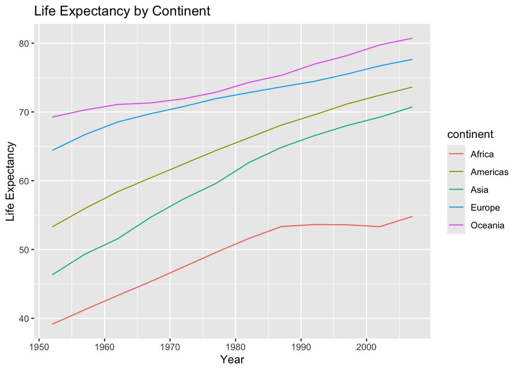

```r
# View(data3)


# line plot to show change by continent
ggplot(data3, aes(x = year, y = mean_life_exp, color = continent)) +
  geom_line() +
  labs(title = "Life Expectancy by Continent",
       x = "Year", y = "Life Expectancy")
```

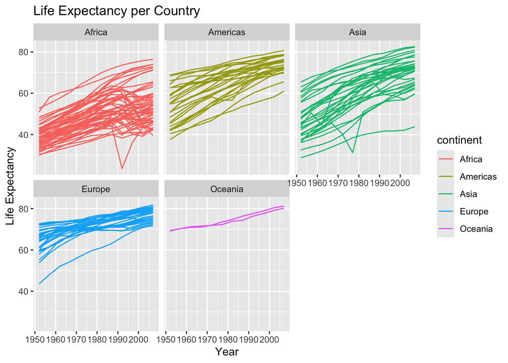

```r
# faceting by continent
ggplot(data, aes(x = year, y = life_exp, color = continent, group = country)) +
  geom_line() +
  facet_wrap(~continent) +
  labs(title = "Life Expectancy per Country",
       x = "Year", y = "Life Expectancy")
```

# Skills Application – Lab

Create a **new R Markdown file** in your project > Week 3.  
Name it: `Lastname_Firstname_Week3`.

Follow the prompts below. For each plot, remember to include **labels**:  
`labs(title = ..., x = ..., y = ...)`.

### 1. Summarize

- Use `group_by()` and `summarise()` to calculate an **average** of a numeric variable for each individual or each group.
- Then use `arrange()` to order results from highest to lowest (hint: desc() is largest to smallest values).

### 2. Visualize Group Means

- Make a bar plot (`geom_col()`) showing the **average** life expectancy for each group.
- Change the fill colors to something you like.

### 3. Boxplot Challenge

- Create a boxplot comparing values across groups. Pick any numeric vairable and summarize it’s mean across groups of observations (the groups can be social group, individual name, country, observer, and so on).
- Try filtering to only a particular year.
- Add axis labels and a title.

### 4. Histogram vs Density

- Plot the distribution of life expectancy using both histogram and density.
- Which gives you more insight? Write a short note in your Markdown file.

### 5. Your Choice

- Pick *any numeric variable*.
- Summarize by continent or year.
- Make one visualization that best shows the differences.

# This Week’s Takeaway

- `group_by()` + `summarise()` create summary tables.
- Visualizations (bar, boxplot, line) can reveal group differences and changes over time.
- Next week: **joins** — combining datasets together.